# Mise en oeuvre de la caméra IP Wanscam JW0008

## Présentation

La caméra IP Wanscam est conçue pour être installée en intérieur. Elle peut être reliée via un câble réseau Ethernet RJ45 ou sans fil en WiFi B/G/N.

[figure not shown]

La caméra IP Wanscam JW0008

Ses caractèristiques principales sont :

- Résolution de l’image 640x480 (VGA) ou 320x240 (QVGA)
- Lentille : f 3,6mm
- Eclairage IR à 10 LED pour une vision de nuit jusqu’à 10 mètres.
- Filtre IR-CUT
- Compression vidéo : MJPEG

```
Ne jamais tourner la caméra à la main, cela pourrait endommager son mécanisme.
```

## Branchement de la caméra

- Vissez l’antenne Wifi sur son connecteur sans forcer.
- Branchez un câble réseau RJ45 sur la prise réseau.
- Connectez la fiche de l’adaptateur secteur sur la prise “Power DC” de la caméra puis connectez l’adaptateur secteur sur une prise de courant.
- Attendez 1 minute environ que la caméra démarre.

Lors de son démarrage, la caméra s’est autoconfigurée avec une adresse IP fournie par un serveur DHCP présent sur votre réseau.

La caméra est utilisable et administrable à partir d’un navigateur web.

```
Suivant les modèles, le port par défaut de la caméra est 99 (ou 81).
```

L’accès se fait via `http://ip-de-la-camera:99/` avec le compte `admin` sans mot de passe.

Par exemple :

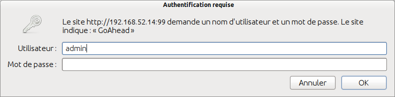

La page d’accueil permet de choisir (la langue et) le lien adapté à son navigateur :

[figure not shown]

Par exemple pour Firefox :

[figure not shown]

En naviguant, on peut accéder à la page d’administration :

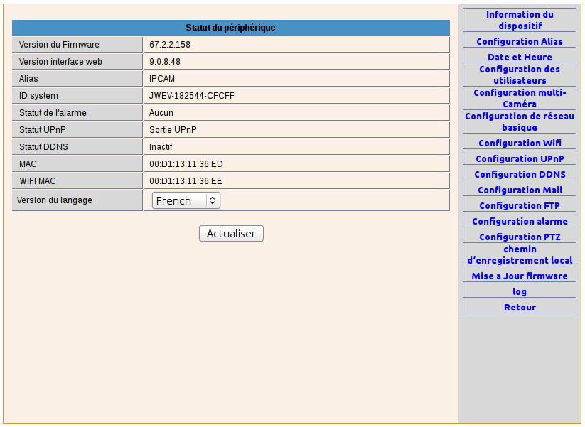

## Tests CGI

Il est conseillé de lire la [documentation](http://tutoriels.domotique-store.fr/images/WANSCAM/api/Wanscam%20IP_Camera_CGI_Manual2.pdf) de la caméra qui précise l’exploitation des programmes CGI.

```
CGI (Common Gateway Interface) est une interface utilisée par les serveurs HTTP. Elle a été normalisée par la RFC 3875. Au lieu d'envoyer le contenu d'un fichier (fichier HTML, image), le serveur HTTP exécute un programme, puis retourne le contenu généré. CGI est le standard industriel qui indique comment transmettre la requête du serveur HTTP au programme, et comment récupérer la réponse générée. Une des caractéristiques de l'interface CGI est d'être indépendante de tout langage de programmation, car elle utilise les flux standard et les variables d'environnement. Même si le langage Perl a historiquement été souvent utilisé pour en écrire, il est possible d'écrire un programme CGI en C, Python, PHP, script shell, en VB ou en tout autre langage de programmation.
```

### Informations

Quelques CGI fournissant des informations sur la caméra Wanscam JW0008 :

- `http://ip-de-la-camera:99/get_status.cgi?user=admin&pwd=`

```
var alias="IPCAM";
var deviceid="JWEV-182544-CFCFF";
var sys_ver="67.2.2.158";
var now=1439042444;
var alarm_status=0;
var upnp_status=1;
var dnsenable=0;
var osdenable=0;
var syswifi_mode=1;
var mac="00:D1:13:11:36:ED";
var wifimac="00:D1:13:11:36:EE";
var dns_status=0;
var authuser=0;
var devicetype=21037151;
var devicesubtype=0;
var externwifi=1;
var record_sd_status=0;
var sdtotal=0; var sdfree=0;
```

- `http://ip-de-la-camera:99/get_camera_params.cgi?user=admin&pwd=`

```
var resolution=0;
var vbright=1;
var vcontrast=128;
var vhue=64;
var vsaturation=80;
var OSDEnable=0;
var mode=0;
var flip=0;
var enc_framerate=30;
var sub_enc_framerate=15;
var speed=10;
var enc_bitrate=2048;
var ircut=1;
```

- `http://ip-de-la-camera:99/get_params.cgi?user=admin&pwd=`

```
var now1=1439042914;
var tz=-28800;
var ntp_enable=1;
var ntp_svr="time.nist.gov";
var dhcpen=1;
var ip="192.168.52.14";
var mask="255.255.255.0";
var gateway="192.168.52.1";
var dns1="8.8.8.8";
var dns2="192.168.52.1";
var port=99;
var dev2_host="192.168.1.111";
var dev2_alias="IPCAM";
var dev2_user="ipc";
var dev2_pwd="";
var dev2_port=99;
...
var user1_name="";
var user1_pwd="";
...
var wifi_enable=1;
var wifi_ssid="wanscam_office";
var wifi_mode=0;
var wifi_encrypt=0;
var wifi_authtype=4;
var wifi_defkey=0;
var wifi_keyformat=0;
var wifi_key1="";
var wifi_key2="";
var wifi_key3="";
var wifi_key4="";
var wifi_key1_bits=0;
var wifi_key2_bits=0;
var wifi_key3_bits=0;
var wifi_key4_bits=0;
var wifi_wpa_psk="88888888";
var wifi_channel=0;
var pppoe_enable=0;
var pppoe_user="";
var pppoe_pwd="";
var upnp_enable=1;
var ddns_service=0;
var ddns_proxy_svr="http://ipcpnp.com/upgengxin.asp";
var ddns_host="";
var ddns_user="";
var ddns_pwd="";
var ddns_proxy_port=80;
var ddns_mode=1;
var ddns_status=0;
var mail_sender="";
var mail_receiver1="";
...
var mailssl=0;
var mail_svr="";
var mail_user="";
var mail_pwd="";
var mail_port=0;
var mail_inet_ip=0;
var ftp_svr="";
var ftp_user="";
var ftp_pwd="";
var ftp_dir="";
var ftp_port=0;
var ftp_mode=0;
var ftp_upload_interval=0;
var ftp_filename=7383708;
var alarm_motion_armed=0;
var alarm_motion_sensitivity=0;
var alarm_input_armed=0;
var alarm_ioin_level=0;
var alarm_mail=0;
var alarm_iolinkage=0;
var alarm_ioout_level=0;
var alarm_upload_interval=0;
var alarm_presetsit=0;
var alarm_snapshot=0;
var alarm_record=0;
var alarm_schedule_enable=0;
var alarm_http=0;
var alarm_http_url="";
var alarm_schedule_sun_0=0;
var alarm_schedule_sun_1=0;
var alarm_schedule_sun_2=0;
var alarm_schedule_mon_0=0;
var alarm_schedule_mon_1=0;
var alarm_schedule_mon_2=0;
var alarm_schedule_tue_0=0;
var alarm_schedule_tue_1=0;
var alarm_schedule_tue_2=0;
var alarm_schedule_wed_0=0;
var alarm_schedule_wed_1=0;
var alarm_schedule_wed_2=0;
var alarm_schedule_thu_0=0;
var alarm_schedule_thu_1=0;
var alarm_schedule_thu_2=0;
var alarm_schedule_fri_0=0;
var alarm_schedule_fri_1=0;
var alarm_schedule_fri_2=0;
var alarm_schedule_sat_0=0;
var alarm_schedule_sat_1=0;
var alarm_schedule_sat_2=0;
```

- `http://ip-de-la-camera:99/get_log.cgi?user=admin&pwd=`

etc …

### Photo et vidéo

Les CGI fournissant l’accès à la prise de photo et au flux vidéo de la caméra Wanscam JW0008 :

- Photo : `http://ip-de-la-camera:99/snapshot.cgi`
- Vidéo : `http://ip-de-la-camera:99/videostream.cgi?user=admin&pwd=&resolution=32&rate=0`

Lire : les formats d’image

### Commandes de déplacement

Les CGI fournissant les commandes de déplacement de la caméra Wanscam JW0008 :

- Monter : `http://adresse-ip-camera:99/decoder_control.cgi?command=0&onestep=1&user=admin&pwd=`
- Descendre : `http://adresse-ip-camera:99/decoder_control.cgi?command=2&onestep=1&user=admin&pwd=`
- Gauche : `http://adresse-ip-camera:99/decoder_control.cgi?command=4&onestep=1&user=admin&pwd=`
- Droite : `http://adresse-ip-camera:99/decoder_control.cgi?command=6&onestep=1&user=admin&pwd=`

etc …

## API Qt

Il est possible ici d’utiliser le module `QtNetwork` qui fournit notamment la classe `QNetworkAccessManager` pour envoyer des requêtes et recevoir des réponses.

Il faut tout d’abord activer le module `QtNetwork` dans son fichier de projet `.pro` :

```
...
QT += network
...
```

Documentation : [La classe QNetworkAccessManager en Qt4 (en)](http://doc.qt.io/qt-4.8/qnetworkaccessmanager.html)

Son fonctionnement est assez simple :

```cpp
QNetworkAccessManager *manager;

// instancie la classe QNetworkAccessManager
manager = new QNetworkAccessManager(this);

// à la fin de l'envoie de la requête, on déclenchera le slot qui réceptionne les données reçues dans la réponse
connect(manager, SIGNAL(finished(QNetworkReply*)), this, SLOT(replyFinished(QNetworkReply*)));

// on émet une requête pour déplacer la caméra à droite
QString URL = "http://192.168.52.14:99/decoder_control.cgi?command=6&onestep=1&user=admin&pwd=";
manager->get(QNetworkRequest(QUrl(URL)));

// le slot de réception
void replyFinished(QNetworkReply *reply)
{
    if(reply->bytesAvailable())
    {
        //reply->read();
        QByteArray datas = reply->readAll();
        qDebug() << QString::fromUtf8("<IHM::replyFinished()> reply : ") << datas;
    }
}
```

# Travail demandé

## Séquence 1 : Informations et Orientation

Objectif : Être capable de commander la caméra à partir d’une application GUI.

L’application à réaliser devra lire les paramètres (adresse ip/port) d’accès à la caméra dans le fichier INI `wanscam.ini` et permettre de les modifier à partir de l’IHM. On visualisera les données reçues à partir des boutons Infos, Params et Camera params qui correspondent aux requêtes CGI d’informations. La GUI permettra évidemment de commander l’orientation de la caméra (boutons Right, Left, Up, Down et Flip/No Flip)

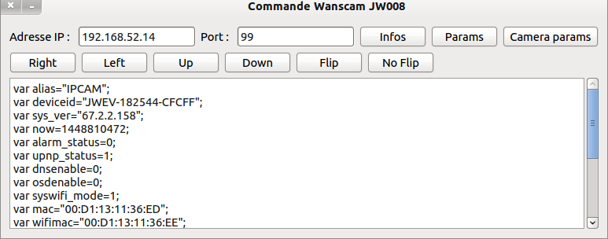

On gèrera aussi les erreurs d’accès :

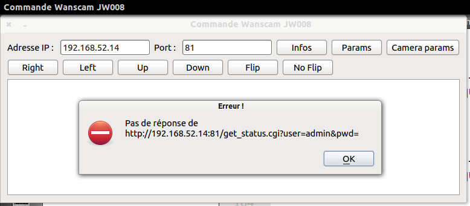

**Code source fourni :** activite-commande-wanscam.zip

1. Compléter l’application fournie et tester.

## Bonus : Photo et Vidéo

Il y a plusieurs possibilités pour accéder au flux vidéo de la caméra. Par exemple, on pourra utiliser :

- la classe `QWebView` pour afficher la page web que fournit la caméra (monitor.htm pour IE, serverpush.htm pour Firefox et mobile.htm pour les mobiles) : voir cette activité.
- la bibliothèque **OpenCV** qui fournit une classe `VideoCapture` pour l’acquisition vidéo en provenance d’une caméra ou d’un fichier : voir cette activité.

Retour au sommaire